# An introduction to flowLearn

Markus Lux

2017-11-15

Identification of cell populations in flow cytometry is a critical part of analysis and lays the groundwork for both clinical diagnostics and research discovery. The current paradigm of manual analysis is time consuming and subjective. If the goal is to match manual analysis, supervised tools provide the best performance, however they require fine parameterization to obtain the best results, Hence, there is a strong need for methods that are fast to setup, accurate and interpretable at the same time. FlowLearn is a semi-supervised approach for the quality-checked identification of cell populations. Using as few as one manually gated sample, through density alignments it is able to predict gates on other samples with high accuracy and speed. Our tool achieves $F_1$-measures exceeding $F_1 > 0.99$ for many populations and $F_1 > 0.90$ for the overwhelming majority. Furthermore, users can directly interpret and adjust automated gates on new sample files to iteratively improve the initial training.

This vignette is intended to give a few working code examples on how to use flowLearn. For more information on the method, please have a look at the corresponding paper. The flowLearn `R` documentation is a helpful resource, too.

## Initializing flowLearn

FlowLearn can be loaded by using

```r
library(flowLearn)
```

It depends on four libraries which are all available in the standard `R` ecosystem:

- `dtw`
- `parallel`
- `stringr`
- `cluster`

All flowLearn methods have the prefix `fl` in order to avoid clashes with other packages.

## Example data

The `flowLearn` package provides example data that is used in this vignette. It contains pre-computed densities from three samples of the “Mice” data set from the original paper, and corresponding evaluation data.

1. `flSampleDensdat` – a `DensityData` object. This is flowLearn’s main data structure, containing density and gate information of all samples. In order to apply flowLearn, all data has to be converted into this format. Learn more about it by running `?DensityData` or read the corresponding section of this vignette.
2. `flSampleBcellEvaluationData` – Data needed for evaluating the B-cell population in this vignette, in particular true gate assignments and parent expressions. This is necessary for evaluation purposes only.
3. `flSampleFlowFrame` – A flowCore::flowFrame object that was read from an FCS file containing a clean population of CD45 cells. To reduce its size, its expressions contain only the `GR1` and `CD43` channels. These are needed for gating Granulocytes. The flowFrame is used to demonstrate the construction of `DensityData` objects.

To keep the file size small, we provide only very few samples and evaluate only one population. Keep in mind that one sample contains around 300k to 500k cells.

Let’s print the example samples and populations:

```r
samples <- unique(flSampleDensdat@data$fcs)
populations <- unique(flSampleDensdat@data$population)
print(samples)
```

```
## [1] "BM_L000130112_A11_002.labelled.fcs"
## [2] "BM_L000076074_F11_011.labelled.fcs"
## [3] "BM_L000074792_B12_004.labelled.fcs"
```

```r
print(populations)
```

```
##  [1] "notgranulocytepre" "granulocytepre"    "cd3tcell"
##  [4] "notcd3tcell"       "plasma"            "notplasma"
##  [7] "bcell"             "myeloid"           "cd43p"
## [10] "cd43n"             "hfa"               "hfb"
## [13] "hfc"               "hfd"               "hfe"
## [16] "hff"
```

We can also plot the density of one sample for the `notplasma` population using the second channel:

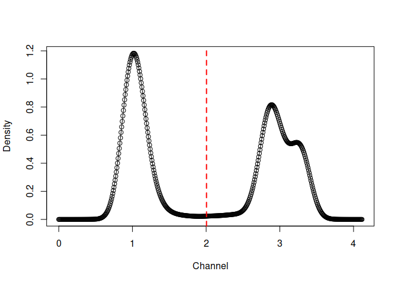

```r
# Select the first sample as an example.
sampleIdx <- 1
fcsName <- samples[[sampleIdx]]

# Use flFind() to filter the second channel density of the notplasma population with the given sample.
dd <- flFind(flSampleDensdat, paste0('population == "notplasma" & channelIdx == 2 & fcs == "', fcsName, '"'))

# Use flPlotDensThresh() to plot the selected density and threshold.
flPlotDensThresh(flGetDensity(dd), flGetGate(dd))
```

## Selecting prototypes

Having covered the basics of flowLearn, we can now let it gate one channel of the `bcell` population (the gate consists of only one channel). In order to do that, it is necessary to first select a prototype:

```r
# Extract all densities of the bcell population and the first channel.
dd <- flFind(flSampleDensdat, 'population == "bcell" & channelIdx == 1')

# Use flSelectPrototypes() to select one prototype.
protoIdx <- flSelectPrototypes(dd, 1)

print(paste0('Selected prototype index: ', protoIdx))
```

```
## [1] "Selected prototype index: 2"
```

In our example, selecting the prototype is trivial. In the real-world, we would not have only three samples, but many more. Choosing the correct prototype(s) there is important.

## Predicting thresholds

Having the prototype identified, it is now the task of predicting thresholds on all non-prototype samples.

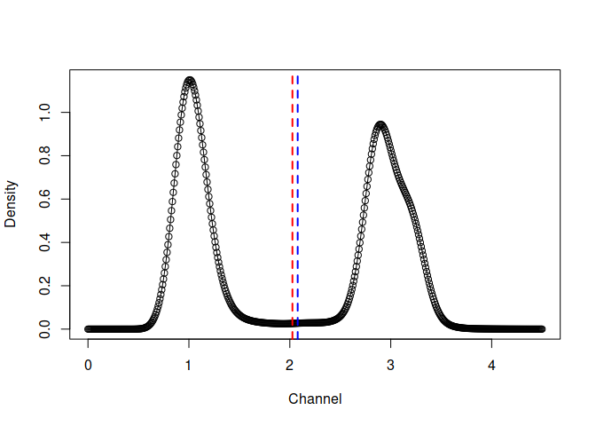

```r
# Use flPredictThresholds() to predict thresholds using a given prototype
# All other samples are aligned with the prototype and its threshold is transferred.
ddp <- flPredictThresholds(dd, protoIdx)

# Plot predictions the prediction, exemplary for the third sample
# Using flAt(), the density at index 3 is extracted for display.
# flGetDensity() and flGetGate() extract its density and gate, respectively.
flPlotDensThresh(flGetDensity(flAt(ddp, 3)), flGetGate(flAt(dd, 3)), flGetGate(flAt(ddp, 3)))
```

It is visible that the predicted threshold (blue) matches up well with the true threshold (red).

Let’s look at the corresponding alignment:

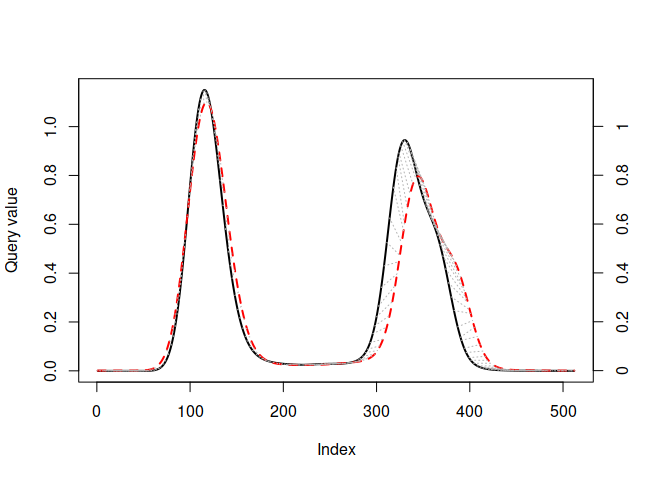

```r
# Re-do the alignment for the purpose of visualization.
# The third density is aligned to the prototype density.
# Here
d <- flDtwMain(flGetDensity(flAt(dd, 3)), flGetDensity(flAt(dd, protoIdx)))

# Use the dtw package's plotting routine.
plot(d, type = 'twoway', lwd = 2, offset = 0.001, match.indices = 200)
```

Here, the red-dashed density denotes the prototype and the solid black one is the predicted density.

## Evaluating predictions of all FCS files

Until now we have shown that the alignment works qualitatively. Let’s now quantitatively evaluate the $F_1$-scores. For that, we compare the predicted to the true gate assignments provided in `flSampleBcellEvaluationData`. We re-use the predicted densities stored in `ddp`:

```r
# Calculate the F1 score for each sample
f1Scores <- sapply(samples, function(fcs)
{

    # The function flEvalF1ScoreFCS() takes the predicted DensityData object, an FCS sample name,
    # the predicted population name, true gate assignments and parent population expressions.
    # It gates the child population using the predicted gates and compares the result to
    # the true population in terms of precision, recall and effectively F1 score.

    flEvalF1ScoreFCS(ddp,
                     fcs,
                     'bcell',
                     flSampleBcellEvaluationData[[fcs]]$gateAssignments,
                     flSampleBcellEvaluationData[[fcs]]$parentExprs,
                     F)

})

print(f1Scores)
```

```
##                     BM_L000130112_A11_002.labelled.fcs
## precision           1
## recall              0.9995649
## f1                  0.9997824
## trueProportion      0.508194
## predictedProportion 0.5079729
##                     BM_L000076074_F11_011.labelled.fcs
## precision           1
## recall              1
## f1                  1
## trueProportion      0.4784912
## predictedProportion 0.4784912
##                     BM_L000074792_B12_004.labelled.fcs
## precision           1
## recall              0.9970572
## f1                  0.9985264
## trueProportion      0.5198859
## predictedProportion 0.5183559
```

It is visible that the previously selected prototype has perfect F1 = 1, because it predicted itself. All other samples show very good performance.

## Constructing DensityData objects

As already mentioned above, `DensityData` is the main flowLearn data structure. All applications using flowLearn have to use it. The construction is easy:

```r
densdat <- flInit(new('DensityData'))
```

This results in an empty `DensityData` object with the following `1029` variables per density entry:

- `fcs`: FCS file name of the density.
- `population`: Analyzed population of the density.
- `channelIdx`: Identifier of the channel for which the density was calculated.
- 512 x-values of the density
- 512 y-values of the density
- `gate.low`: Lower threshold for this channel (defaults to NaN)
- `gate.high`: Upper threshold for this channel (defaults to NaN)

Now it is the task to add densities that can be used by flowLearn. This is done using the `flAdd()` method. Other methods of the `DensityData` class are given by `??flowLearn::DensityData`.

```r
# Use flEstimateDensity() to obtain a kernel density estimate that is smooth.
# It is given a vector of cell measurements for one channel and the number of density features.
# In this vignette example, the provided flSampleFlowFrame contains only two channels.

densA <- flEstimateDensity(flSampleFlowFrame@exprs[, 1], densdat@numFeatures)
densB <- flEstimateDensity(flSampleFlowFrame@exprs[, 1], densdat@numFeatures)

# Now add the densities to the `densdat` object.
densdat <- flAdd(densdat, flSampleFlowFrame@description$"$FIL", 'granulocytepre', 1, densA$x, densA$y)
densdat <- flAdd(densdat, flSampleFlowFrame@description$"$FIL", 'granulocytepre', 2, densB$x, densB$y)
```

We can now verify that the `DensityData` object contains two densities:

```r
print(flSize(densdat) == 2)
```

```
## [1] TRUE
```

The newly constructed `DensityData` object does not contain threshold information, yet. For this to happen, they have to be either annotated manually or predicted.